# WineQualityReds Data Exploration by Mona Alsbakhi

```
## [1] "C:/Users/test/Desktop/Explore and sammarize data-Mona"
```

```
## 'data.frame':    1599 obs. of  13 variables:
##  $ X                   : int  1 2 3 4 5 6 7 8 9 10 ...
##  $ fixed.acidity       : num  7.4 7.8 7.8 11.2 7.4 7.4 7.9 7.3 7.8 7.5 ...
##  $ volatile.acidity    : num  0.7 0.88 0.76 0.28 0.7 0.66 0.6 0.65 0.58 0.5 ...
##  $ citric.acid         : num  0 0 0.04 0.56 0 0 0.06 0 0.02 0.36 ...
##  $ residual.sugar      : num  1.9 2.6 2.3 1.9 1.9 1.8 1.6 1.2 2 6.1 ...
##  $ chlorides           : num  0.076 0.098 0.092 0.075 0.076 0.075 0.069 0.065 0.073 0.071 ...
##  $ free.sulfur.dioxide : num  11 25 15 17 11 13 15 15 9 17 ...
##  $ total.sulfur.dioxide: num  34 67 54 60 34 40 59 21 18 102 ...
##  $ density             : num  0.998 0.997 0.997 0.998 0.998 ...
##  $ pH                  : num  3.51 3.2 3.26 3.16 3.51 3.51 3.3 3.39 3.36 3.35 ...
##  $ sulphates           : num  0.56 0.68 0.65 0.58 0.56 0.56 0.46 0.47 0.57 0.8 ...
##  $ alcohol             : num  9.4 9.8 9.8 9.8 9.4 9.4 9.4 10 9.5 10.5 ...
##  $ quality             : int  5 5 5 6 5 5 5 7 7 5 ...
```

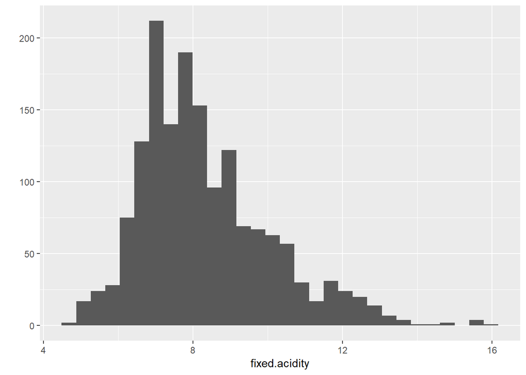

According to the histogram above, the data distribution is right skewed, and concentrated around 7 and there are some outliers.

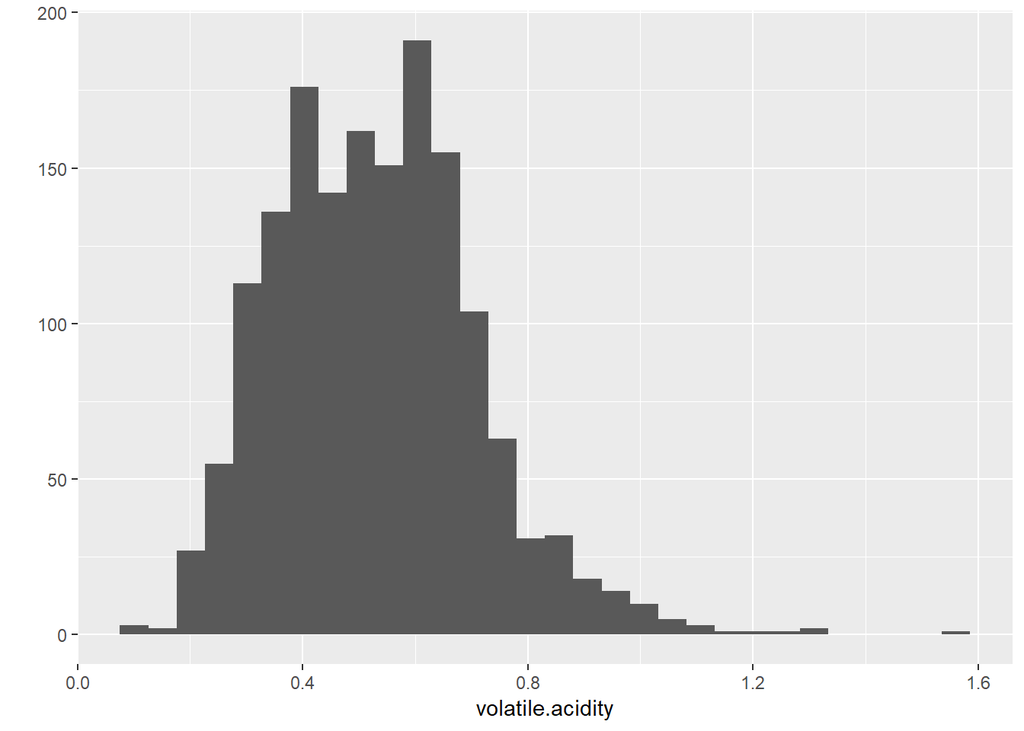

```r
qplot ( volatile.acidity, data = wines, geom = "histogram")
```

According to the histogram above, the data distribution of volatile acidity seem to be right skewed and normally distributed.

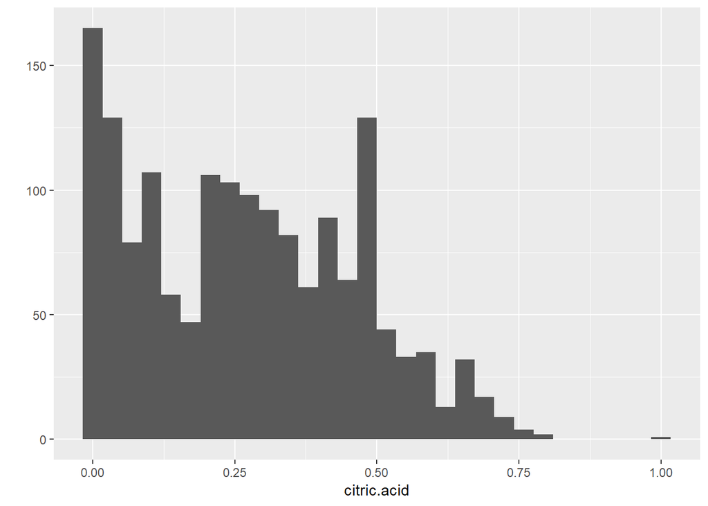

```r
qplot ( citric.acid, data = wines, geom = "histogram")
```

The data distribution of citric acid is not normall distributed.

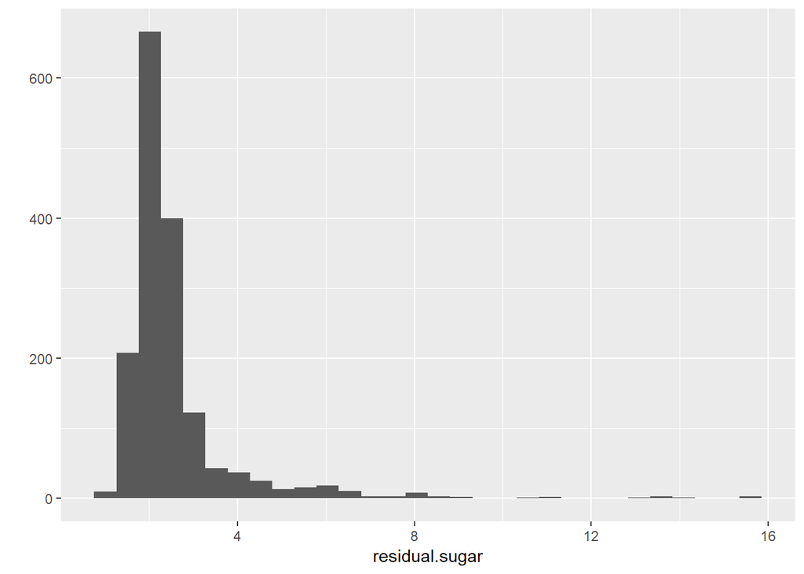

```r
qplot ( residual.sugar, data = wines, geom = "histogram")
```

The distribution of residual sugar is right skewed, and concentrated around point 2 and There are some outliers.

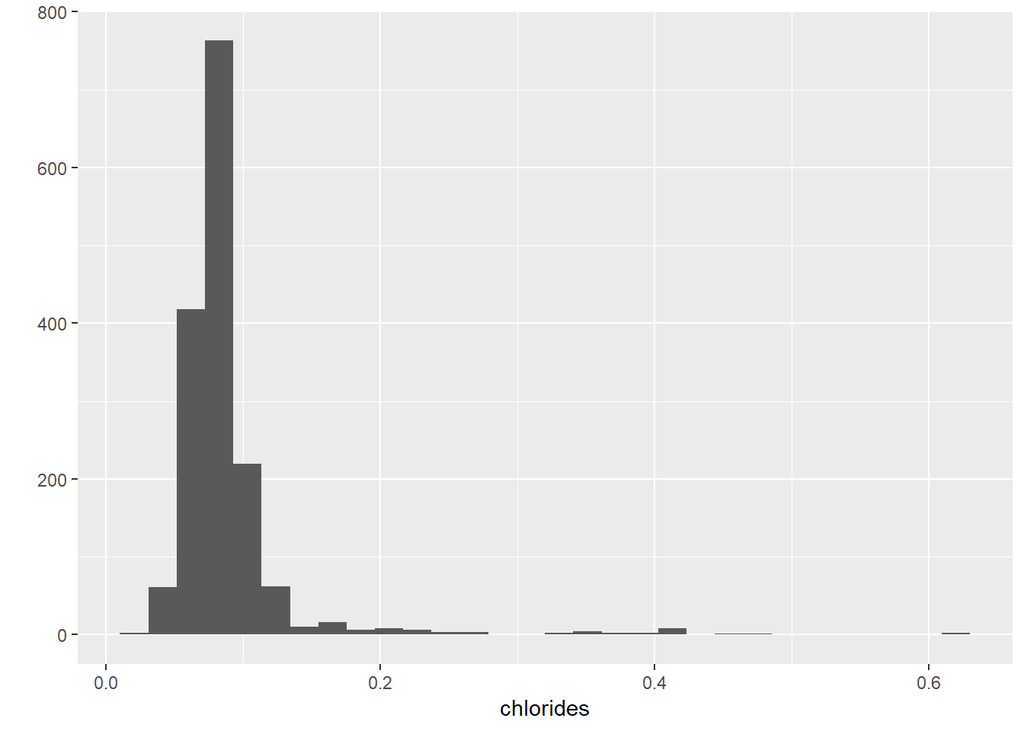

```r
qplot ( chlorides, data = wines, geom = "histogram")
```

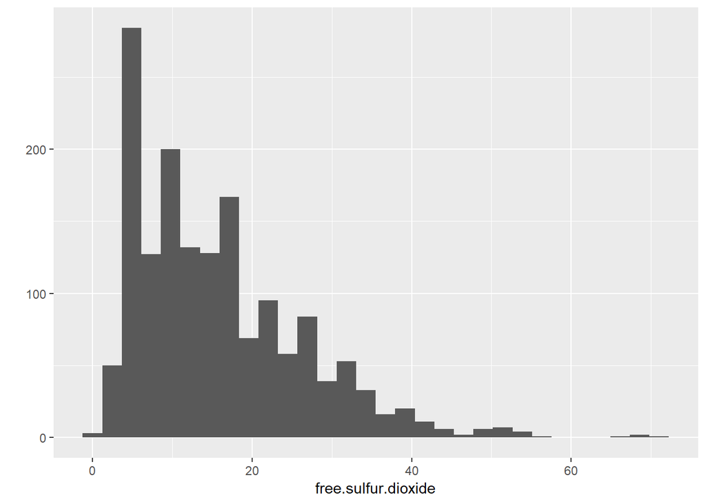

```r
qplot ( free.sulfur.dioxide, data = wines, geom = "histogram")
```

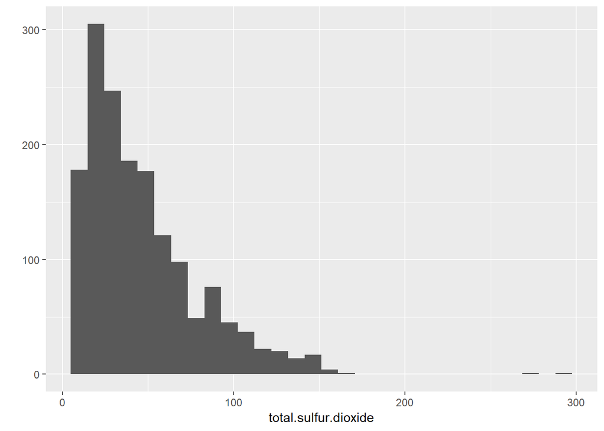

```r
qplot ( total.sulfur.dioxide, data = wines, geom = "histogram")
```

According to tha histogram the data distribution of total sulfur dioxide is right skewed and concentrated around point 28, there are some ouliers.

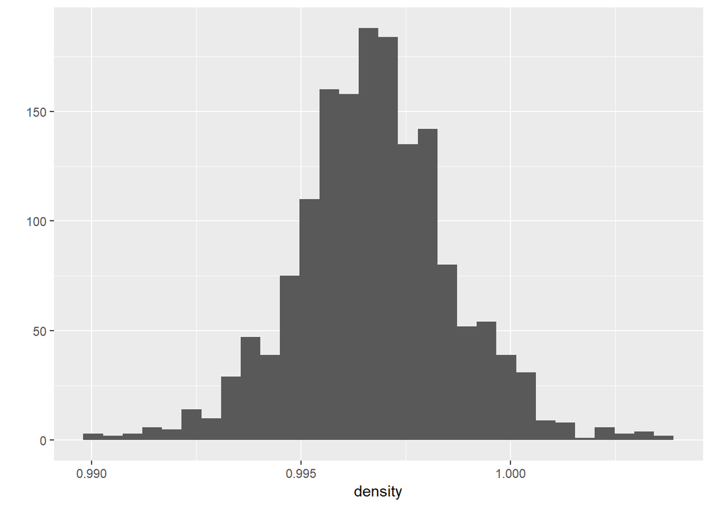

```r
qplot ( density, data = wines, geom = "histogram")
```

The distribution of density is normally and concentrated around 0.996, there are few ouliers.

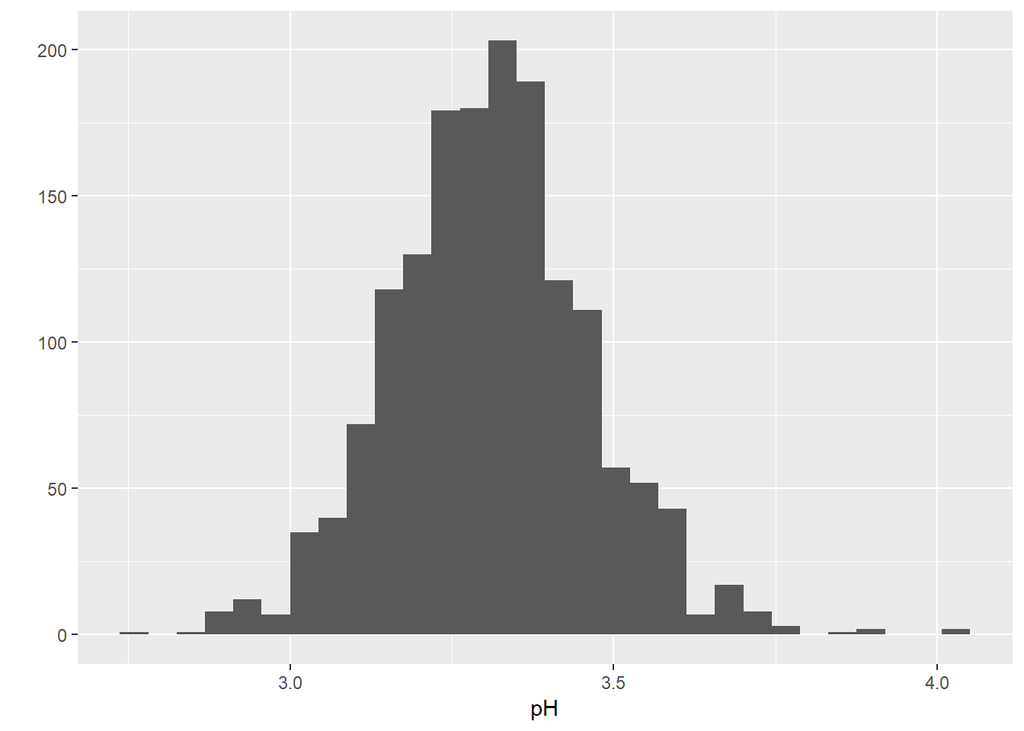

```r
qplot ( pH, data = wines, geom = "histogram")
```

The distribution of pH is normally and concentrated around point 3.32

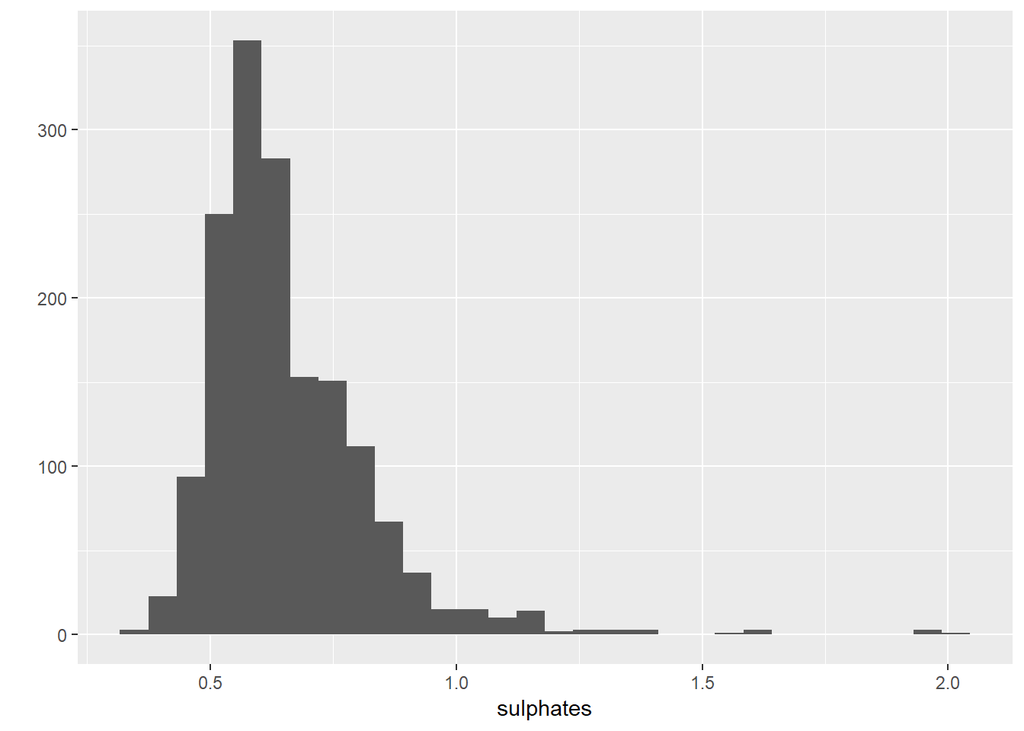

```r
qplot ( sulphates, data = wines, geom = "histogram")
```

The distribution of sulphates is right skewed and concentrated around 0.66, there are some ouliers.

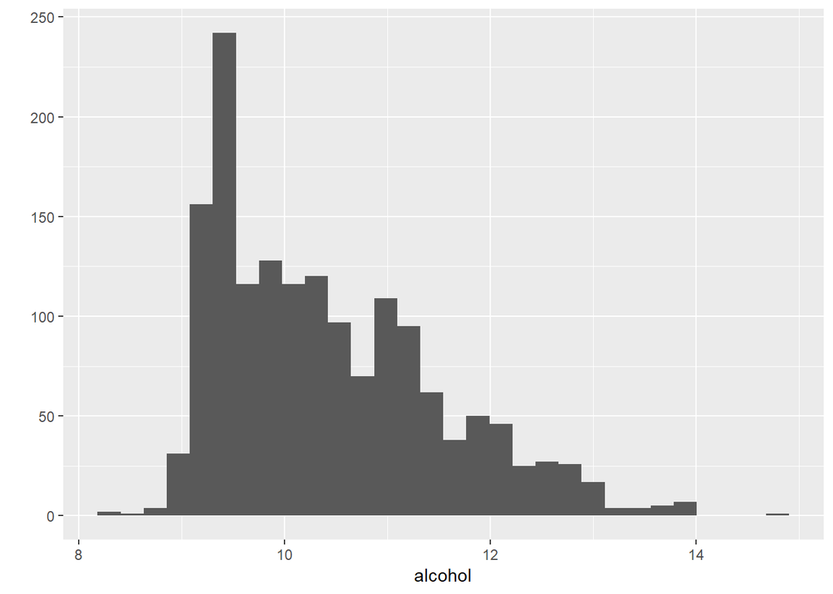

```r
qplot ( alcohol, data = wines, geom = "histogram")
```

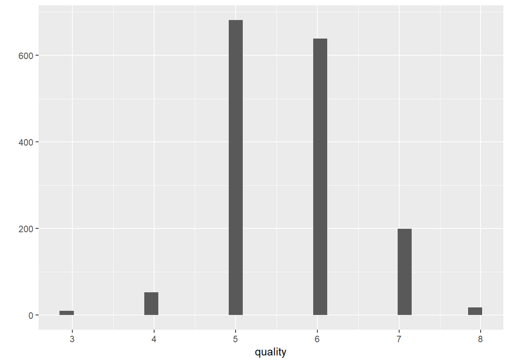

```r
qplot ( quality, data = wines, geom = "histogram")
```

[output not shown]

```r
install.packages("corrplot", repos="http://cran.rstudio.com/")
M <- cor(wines)
```

[output not shown]

```r
corrplot(M, method = "number", number.cex=0.7)
```

[output not shown]

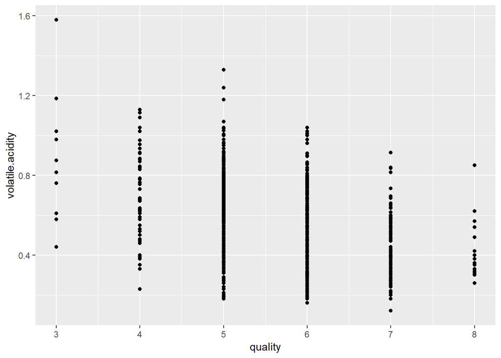

```r
qplot ( quality,volatile.acidity , data= wines, geom= "point")
```

The graph shows the lower volatile acidity is the higher the quality becomes. The correlation coefficient between quality and volatile acidity is -0.39

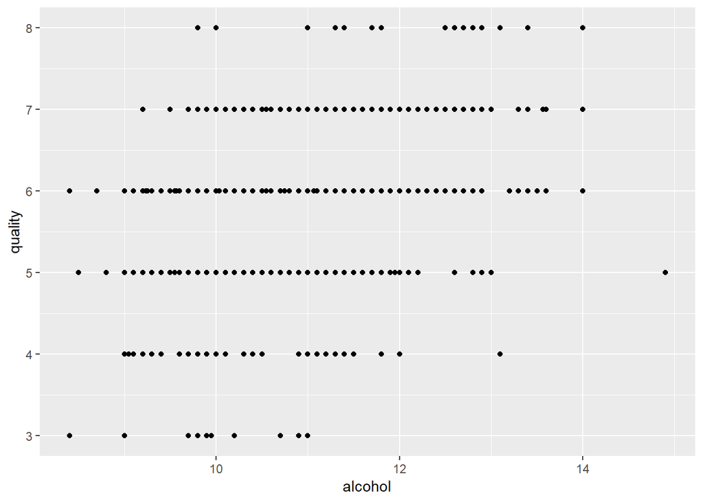

```r
qplot ( alcohol,quality , data= wines, geom= "point")
```

The correlation coefficient between alcohol and quality is 0.48, the graph shows a positive relationship between alcohol and quality level. medium quality and low quality wines have their percent alcohol contents concentrated around 10 whereas high quality wines have their percent alcohol contents concentrated around 12.

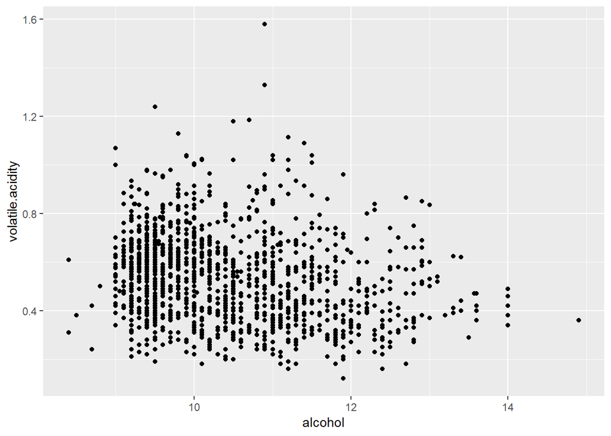

```r
qplot ( alcohol,volatile.acidity , data= wines, geom= "point")
```

A weak negative correlation of -0.2 exists between percent alcohol content and volatile acidity.

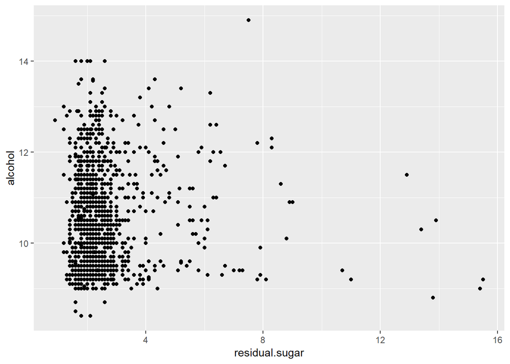

```r
qplot ( residual.sugar,alcohol , data= wines, geom= "point")
```

The correlation coefficient between residual sugar and alcohol is 0.04, which indicates that there is almost no relationship between residual sugar and alcohol

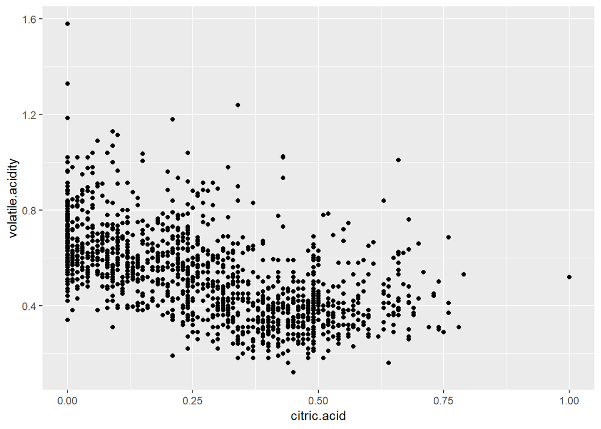

```r
qplot ( citric.acid, volatile.acidity , data= wines, geom= "point")
```

There is a negative correlation between citric acid and volatile acidity with correlation coofficient of -0.55

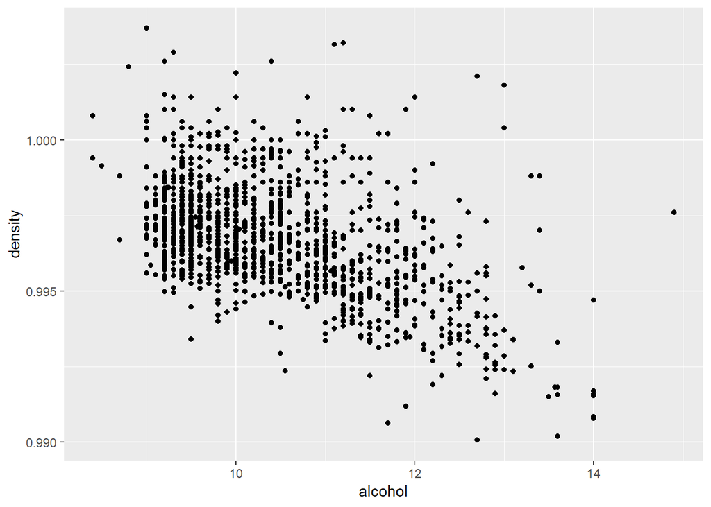

```r
qplot ( alcohol, density , data= wines, geom= "point")
```

The correlation coefficient between alcohol and density is -0.5, so when alcohol content increases, the density decreases.

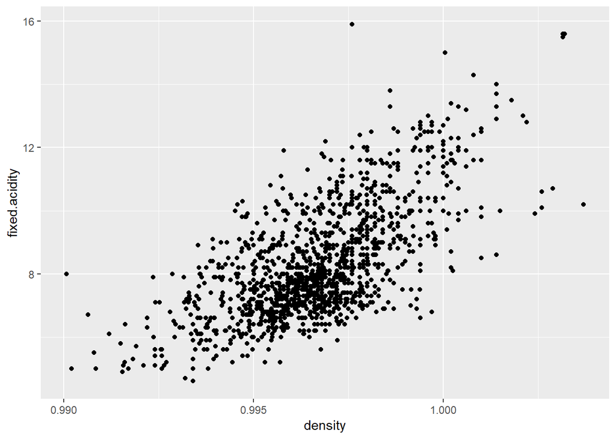

```r
qplot ( density,fixed.acidity, data= wines, geom= "point")
```

This graph shows positive relationship between density and fixed acidity with correlation coefficient of 0.67

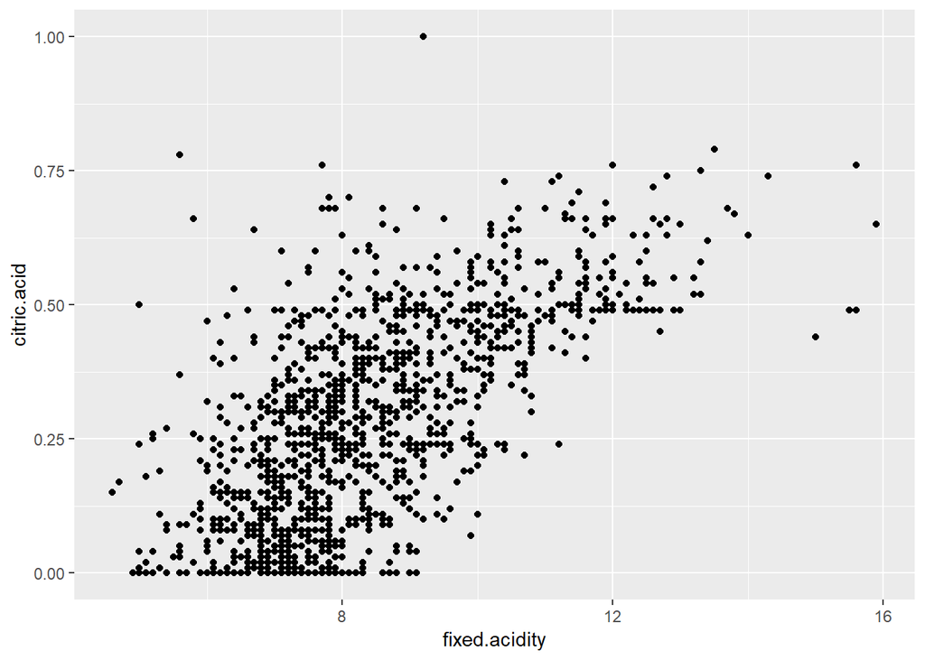

```r
qplot ( fixed.acidity, citric.acid, data= wines, geom= "point")
```

This graph shows positive relationship between fixed acidity and citric acid with correlation coefficient of 0.67

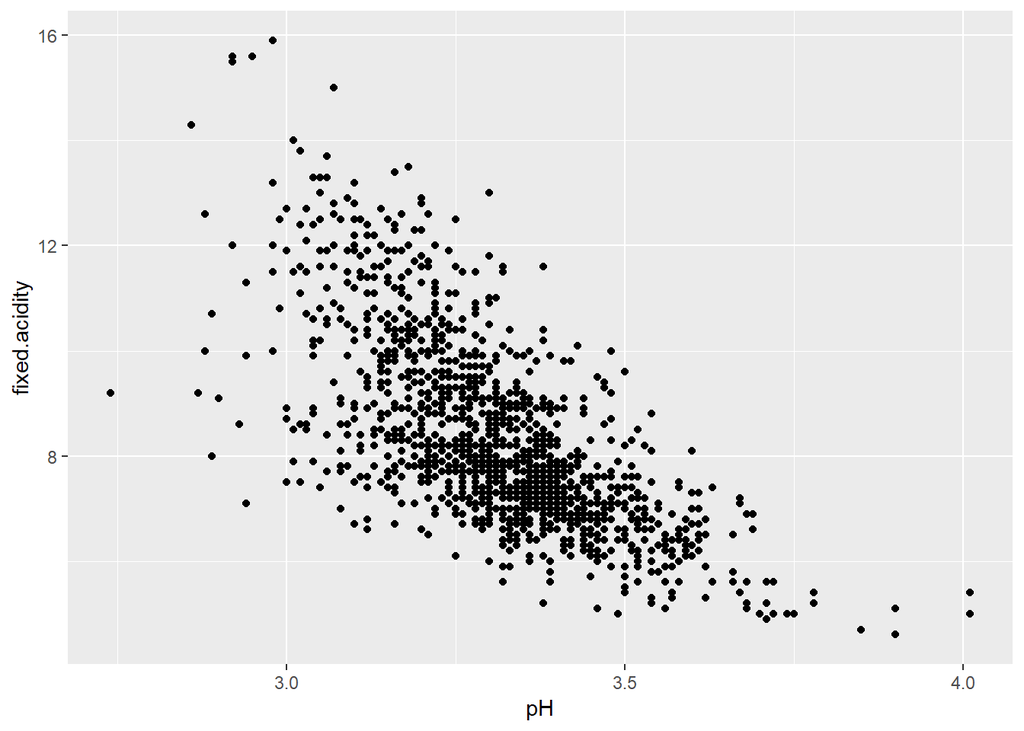

```r
qplot ( pH, fixed.acidity, data= wines, geom= "point")
```

This graph shows negative relationship between pH and fixed acidity with correlation coefficient of -0.68

# Bivariate Analysis

### Talk about some of the relationships you observed in this part of the investigation. How did the feature(s) of interest vary with other features in the dataset?

I observed a negative relationships between quality level and volatile acidity, and positive correlation between alcohol and quality level.

### Did you observe any interesting relationships between the other features (not the main feature(s) of interest)?

Yes, I observed positive relationship between density and fixed acidity, positive relationship between fixed acidity and citric acid, and negative relationship between pH and fixed acidity. Other variables either show very weak relationship or do not show any relationship.

### What was the strongest relationship you found?

Quality is negatively correlated with volatile acidity and positively and strongly correlated with alcohol, also pH is negatively and strongly correlated with fixed acidity.

# Multivariate Plots Section

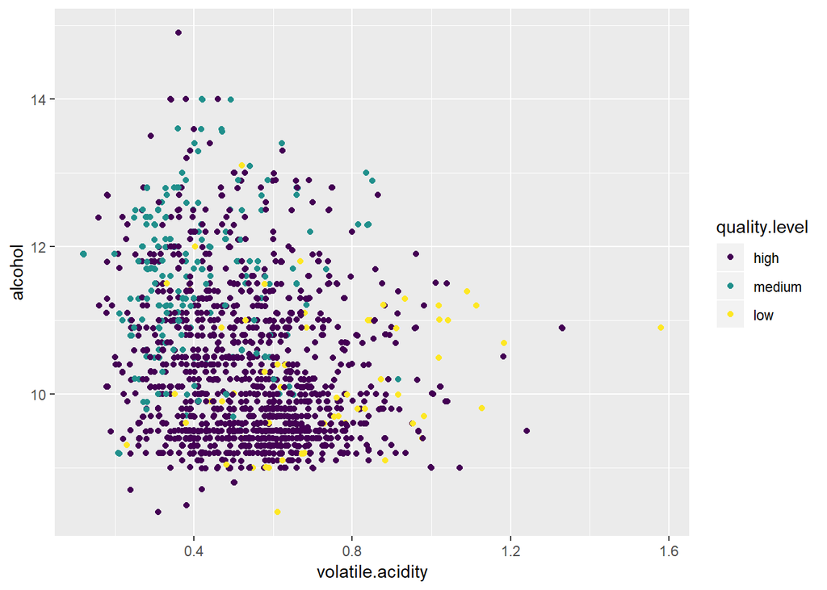

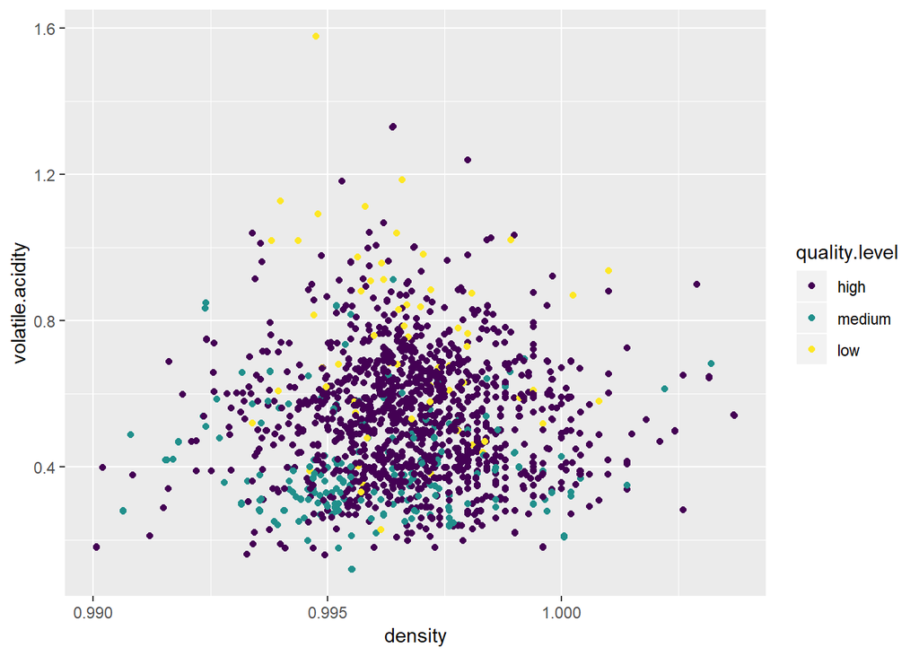

```r
qplot (density, volatile.acidity, aes(color= quality.level ), data= wines, geom= "jitter")
```

The densities of high quality wines are concentrated between 0.994 and 0.998, and between 0.2 and 0.9 of volatile acidity.

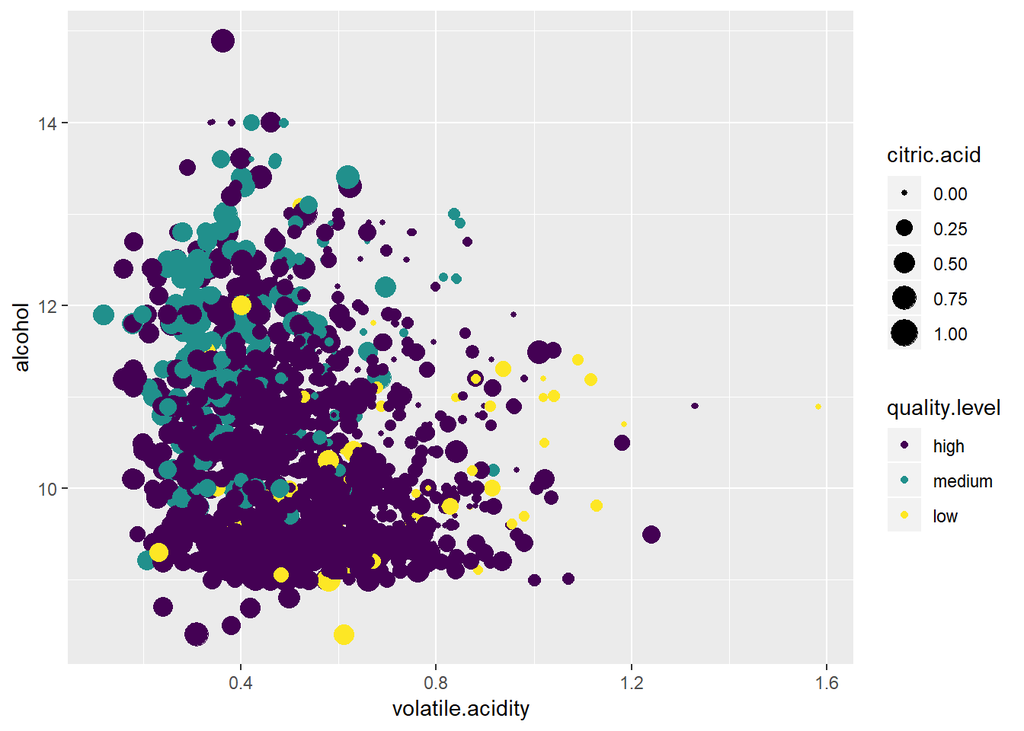

```r
qplot ( volatile.acidity, alcohol, color= quality.level, aes(size= citric.acid ), data= wines, geom= "jitter")
```

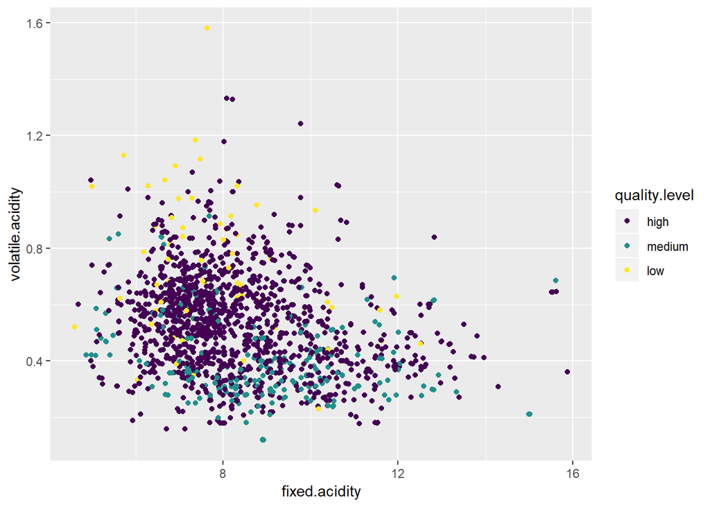

```r
qplot (fixed.acidity, volatile.acidity, aes(color= quality.level ), data= wines, geom= "jitter")
```

The distribution of high quality wines seem to be concentrated at fixed acidity values that are between 6 and 10, for volatile acidity between 0.2 and 0.9

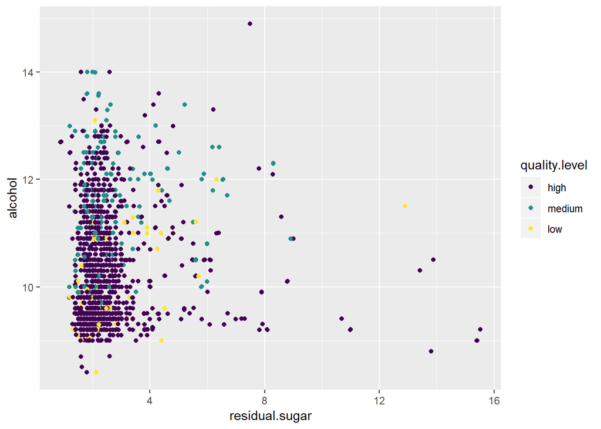

```r
qplot (residual.sugar, alcohol, aes(color= quality.level ), data= wines, geom= "jitter")
```

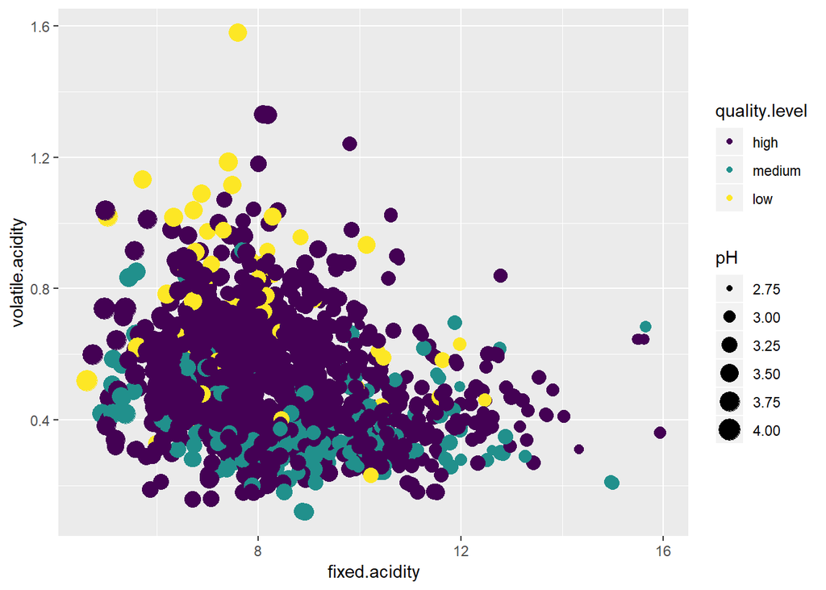

```r
qplot ( fixed.acidity,volatile.acidity, color= quality.level, aes(size= pH ), data= wines, geom= "jitter")
```

According to the graph above, pH increases as fixed acidity decreases.

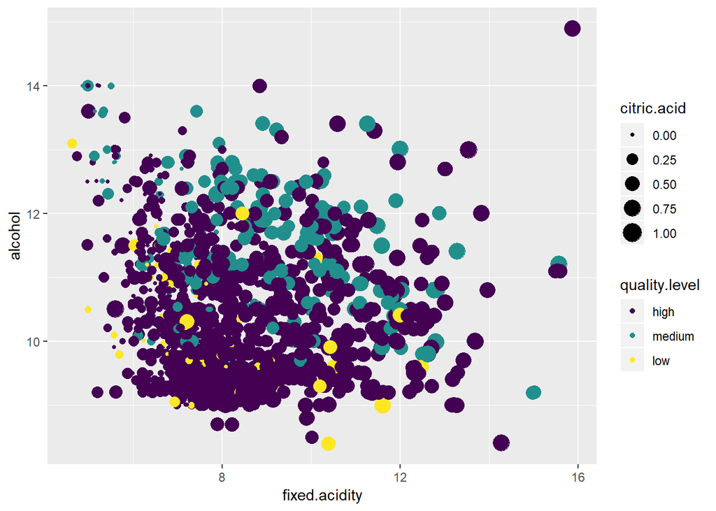

```r
qplot ( fixed.acidity, alcohol, color= quality.level, aes(size= citric.acid ), data= wines, geom= "jitter")
```

According to the graph above, the citric acid increases as fixed acidity increases.

# Multivariate Analysis

### Talk about some of the relationships you observed in this part of the investigation. Were there features that strengthened each other in terms of looking at your feature(s) of interest?

Quality has a weak positive relationship with alcohol, and weak negative relationship with volatile acid, and there is positive relationship between fixed acidity and citric acid.

### Were there any interesting or surprising interactions between features?

Residual sugar, it is an important part in wine taste,but it has very little impact on wine quality.

# Final Plots and Summary

### Plot One

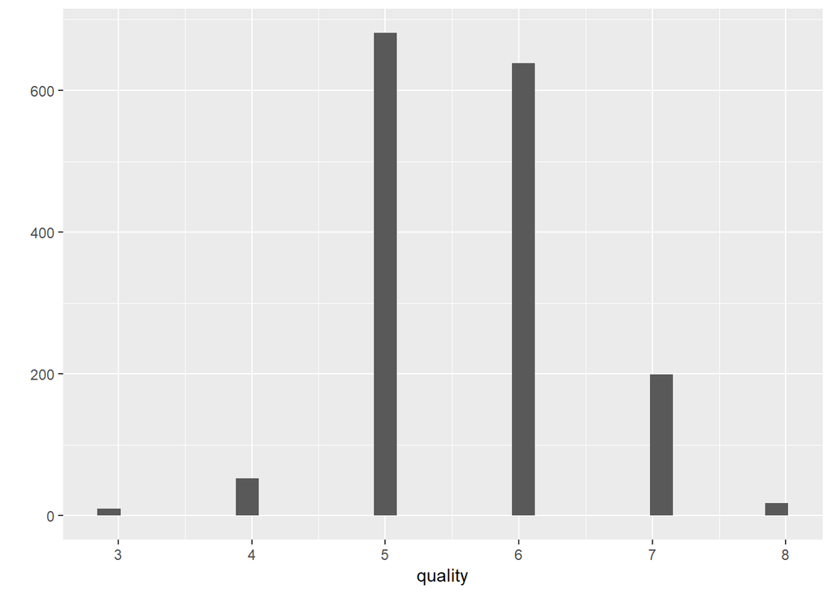

```r
qplot ( quality, data = wines, geom = "histogram")
```

### Description One

The distribution of red wine quality is normal. 83% of wines are rated 5 and 6 (high quality). Although the rating scale is between 0 and 10, there exists no wine that is rated 1, 2, 9 or 10.

### Plot Two

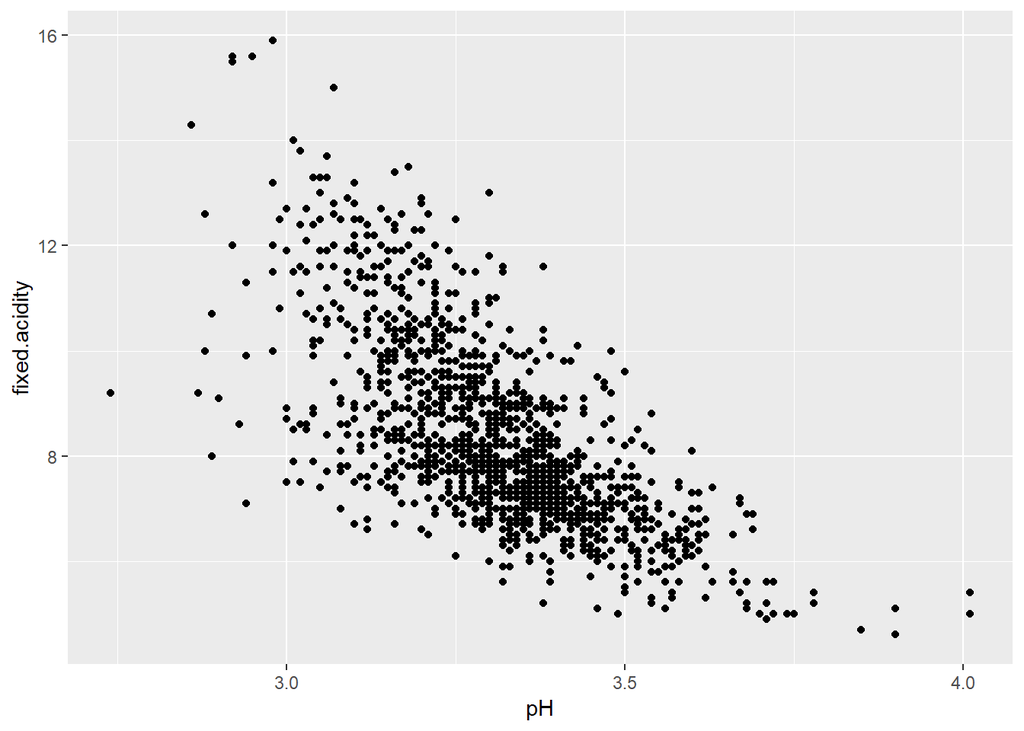

[figure not shown]

## Wine with high percent alcohol content and low volatile acidity tends to be rated as high quality wine. So the volatile acidity in wine and percent alcohol content are two important components in the quality and taste of red wines.

# Reflection

The wines data set contains information on 1599 wines across 12 variables . I understanding the variables in the data set, I put some questions, I explored the quality of wines y creating a quality level variable and categorise the quality into three levels (high, low, medium).There was a relation between the volatile acidity of a wine and its quality. There was also a relation between the alcohol and its quality. Both of them (volatile acidity and alcohol) are two important components in the quality and taste of red wines.The quality of the analysis can be improved by collecting more data, and creating more variables to increase the quality of wine.